# Risk Factor Analysis

## Outcome Variable

**Outcome Variable:** wast_rec90d

## Predictor Variables

**Intervention Variable:** nhh

**Adjustment Set:**

unadjusted

## Stratifying Variables

The analysis was stratified on these variable(s):

- agecat
- studyid
- country

## Data Summary

| agecat | studyid | country | nhh | wast_rec90d | n_cell | n |
| --- | --- | --- | --- | --- | --- | --- |
| 0-24 months | IRC | INDIA | 3 or less | 0 | 17 | 395 |
| 0-24 months | IRC | INDIA | 3 or less | 1 | 32 | 395 |
| 0-24 months | IRC | INDIA | 4-5 | 0 | 61 | 395 |
| 0-24 months | IRC | INDIA | 4-5 | 1 | 75 | 395 |
| 0-24 months | IRC | INDIA | 6-7 | 0 | 47 | 395 |
| 0-24 months | IRC | INDIA | 6-7 | 1 | 60 | 395 |
| 0-24 months | IRC | INDIA | 8+ | 0 | 37 | 395 |
| 0-24 months | IRC | INDIA | 8+ | 1 | 66 | 395 |
| 0-24 months | LCNI-5 | MALAWI | 3 or less | 0 | 16 | 78 |
| 0-24 months | LCNI-5 | MALAWI | 3 or less | 1 | 5 | 78 |
| 0-24 months | LCNI-5 | MALAWI | 4-5 | 0 | 30 | 78 |
| 0-24 months | LCNI-5 | MALAWI | 4-5 | 1 | 4 | 78 |
| 0-24 months | LCNI-5 | MALAWI | 6-7 | 0 | 9 | 78 |
| 0-24 months | LCNI-5 | MALAWI | 6-7 | 1 | 2 | 78 |
| 0-24 months | LCNI-5 | MALAWI | 8+ | 0 | 10 | 78 |
| 0-24 months | LCNI-5 | MALAWI | 8+ | 1 | 2 | 78 |
| 0-24 months | NIH-Birth | BANGLADESH | 3 or less | 0 | 39 | 421 |
| 0-24 months | NIH-Birth | BANGLADESH | 3 or less | 1 | 40 | 421 |
| 0-24 months | NIH-Birth | BANGLADESH | 4-5 | 0 | 88 | 421 |
| 0-24 months | NIH-Birth | BANGLADESH | 4-5 | 1 | 91 | 421 |
| 0-24 months | NIH-Birth | BANGLADESH | 6-7 | 0 | 45 | 421 |
| 0-24 months | NIH-Birth | BANGLADESH | 6-7 | 1 | 55 | 421 |
| 0-24 months | NIH-Birth | BANGLADESH | 8+ | 0 | 30 | 421 |
| 0-24 months | NIH-Birth | BANGLADESH | 8+ | 1 | 33 | 421 |
| 0-24 months | NIH-Crypto | BANGLADESH | 3 or less | 0 | 19 | 310 |
| 0-24 months | NIH-Crypto | BANGLADESH | 3 or less | 1 | 29 | 310 |
| 0-24 months | NIH-Crypto | BANGLADESH | 4-5 | 0 | 63 | 310 |
| 0-24 months | NIH-Crypto | BANGLADESH | 4-5 | 1 | 87 | 310 |
| 0-24 months | NIH-Crypto | BANGLADESH | 6-7 | 0 | 23 | 310 |
| 0-24 months | NIH-Crypto | BANGLADESH | 6-7 | 1 | 46 | 310 |

[output cut: 114 more lines]

The following strata were considered:

- agecat: 0-24 months, studyid: IRC, country: INDIA
- agecat: 0-24 months, studyid: LCNI-5, country: MALAWI
- agecat: 0-24 months, studyid: NIH-Birth, country: BANGLADESH
- agecat: 0-24 months, studyid: NIH-Crypto, country: BANGLADESH
- agecat: 0-24 months, studyid: PROVIDE, country: BANGLADESH
- agecat: 0-24 months, studyid: SAS-FoodSuppl, country: INDIA
- agecat: 0-6 months, studyid: IRC, country: INDIA
- agecat: 0-6 months, studyid: LCNI-5, country: MALAWI
- agecat: 0-6 months, studyid: NIH-Birth, country: BANGLADESH
- agecat: 0-6 months, studyid: NIH-Crypto, country: BANGLADESH
- agecat: 0-6 months, studyid: PROVIDE, country: BANGLADESH
- agecat: 0-6 months, studyid: SAS-FoodSuppl, country: INDIA
- agecat: 6-24 months, studyid: IRC, country: INDIA
- agecat: 6-24 months, studyid: LCNI-5, country: MALAWI
- agecat: 6-24 months, studyid: NIH-Birth, country: BANGLADESH
- agecat: 6-24 months, studyid: NIH-Crypto, country: BANGLADESH
- agecat: 6-24 months, studyid: PROVIDE, country: BANGLADESH
- agecat: 6-24 months, studyid: SAS-FoodSuppl, country: INDIA

### Dropped Strata

Some strata were dropped due to rare outcomes:

- agecat: 0-24 months, studyid: LCNI-5, country: MALAWI
- agecat: 0-24 months, studyid: SAS-FoodSuppl, country: INDIA
- agecat: 0-6 months, studyid: LCNI-5, country: MALAWI
- agecat: 0-6 months, studyid: NIH-Crypto, country: BANGLADESH
- agecat: 0-6 months, studyid: SAS-FoodSuppl, country: INDIA
- agecat: 6-24 months, studyid: LCNI-5, country: MALAWI
- agecat: 6-24 months, studyid: NIH-Crypto, country: BANGLADESH
- agecat: 6-24 months, studyid: PROVIDE, country: BANGLADESH
- agecat: 6-24 months, studyid: SAS-FoodSuppl, country: INDIA

## Methods Detail

We’re interested in the causal parameters $E[Y_a]$ for all values of $a \in \mathcal{A}$. These parameters represent the mean outcome if, possibly contrary to fact, we intervened to set all units to have $A=a$. Under the randomization and positivity assumptions, these are identified by the statistical parameters $\psi_a=E_W[E_{Y|A,W}(Y|A=a,W)]$. In addition, we’re interested in the mean of $Y$, $E[Y]$ under no intervention (the observed mean). We will estimate these parameters by using SuperLearner to fit the relevant likelihood factors – $E_{Y|A,W}(Y|A=a,W)$ and $p(A=a|W)$, and then updating our likelihood fit using a joint TMLE.

For unadjusted analyses ($W=\{\}$), initial likelihoods were estimated using Lrnr_glm to estimate the simple $E(Y|A)$ and Lrnr_mean to estimate $p(A)$. For adjusted analyses, a small library containing Lrnr_glmnet, Lrnr_xgboost, and Lrnr_mean was used.

Having estimated these parameters, we will then use the delta method to estimate relative risks and attributable risks relative to a prespecified baseline level of $A$.

# Results Detail

## Results Plots

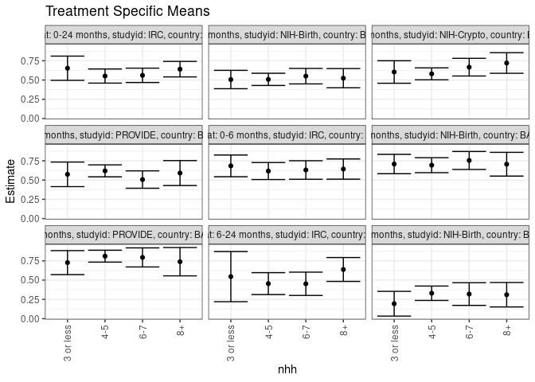

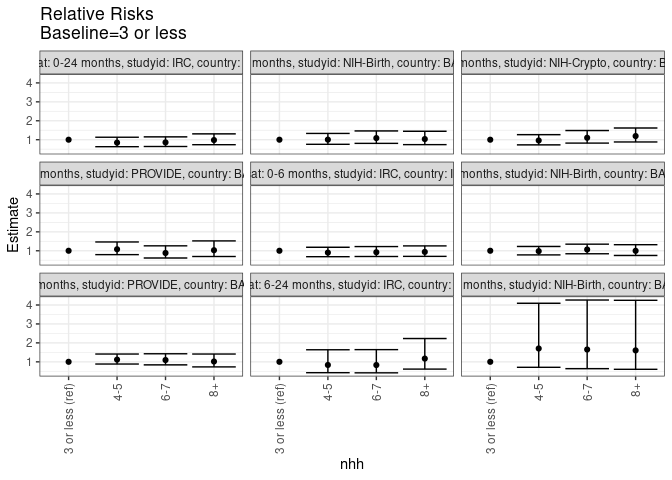

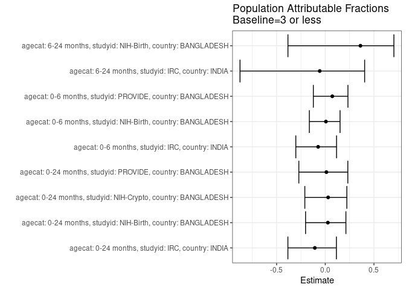

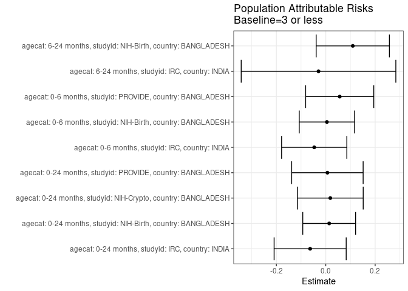

## Results Table

### Parameter: TSM

| agecat | studyid | country | intervention_level | baseline_level | estimate | ci_lower | ci_upper |
| --- | --- | --- | --- | --- | --- | --- | --- |
| 0-24 months | IRC | INDIA | 3 or less | NA | 0.6530612 | 0.4957283 | 0.8103942 |
| 0-24 months | IRC | INDIA | 4-5 | NA | 0.5514706 | 0.4595591 | 0.6433820 |
| 0-24 months | IRC | INDIA | 6-7 | NA | 0.5607477 | 0.4676055 | 0.6538899 |
| 0-24 months | IRC | INDIA | 8+ | NA | 0.6407767 | 0.5401604 | 0.7413930 |
| 0-24 months | NIH-Birth | BANGLADESH | 3 or less | NA | 0.5063291 | 0.3872714 | 0.6253869 |
| 0-24 months | NIH-Birth | BANGLADESH | 4-5 | NA | 0.5083799 | 0.4291011 | 0.5876587 |
| 0-24 months | NIH-Birth | BANGLADESH | 6-7 | NA | 0.5500000 | 0.4493259 | 0.6506741 |
| 0-24 months | NIH-Birth | BANGLADESH | 8+ | NA | 0.5238095 | 0.3992857 | 0.6483333 |
| 0-24 months | NIH-Crypto | BANGLADESH | 3 or less | NA | 0.6041667 | 0.4581362 | 0.7501972 |
| 0-24 months | NIH-Crypto | BANGLADESH | 4-5 | NA | 0.5800000 | 0.5022921 | 0.6577079 |
| 0-24 months | NIH-Crypto | BANGLADESH | 6-7 | NA | 0.6666667 | 0.5519237 | 0.7814097 |
| 0-24 months | NIH-Crypto | BANGLADESH | 8+ | NA | 0.7209302 | 0.5871474 | 0.8547130 |
| 0-24 months | PROVIDE | BANGLADESH | 3 or less | NA | 0.5744681 | 0.4148767 | 0.7340595 |
| 0-24 months | PROVIDE | BANGLADESH | 4-5 | NA | 0.6197183 | 0.5419797 | 0.6974569 |
| 0-24 months | PROVIDE | BANGLADESH | 6-7 | NA | 0.5066667 | 0.3938262 | 0.6195072 |
| 0-24 months | PROVIDE | BANGLADESH | 8+ | NA | 0.5909091 | 0.4288617 | 0.7529564 |
| 0-6 months | IRC | INDIA | 3 or less | NA | 0.6842105 | 0.5433626 | 0.8250585 |
| 0-6 months | IRC | INDIA | 4-5 | NA | 0.6172840 | 0.5071231 | 0.7274448 |
| 0-6 months | IRC | INDIA | 6-7 | NA | 0.6307692 | 0.5104178 | 0.7511207 |
| 0-6 months | IRC | INDIA | 8+ | NA | 0.6428571 | 0.5116435 | 0.7740708 |
| 0-6 months | NIH-Birth | BANGLADESH | 3 or less | NA | 0.7083333 | 0.5824756 | 0.8341911 |
| 0-6 months | NIH-Birth | BANGLADESH | 4-5 | NA | 0.6931818 | 0.5961748 | 0.7901888 |
| 0-6 months | NIH-Birth | BANGLADESH | 6-7 | NA | 0.7547170 | 0.6380983 | 0.8713357 |
| 0-6 months | NIH-Birth | BANGLADESH | 8+ | NA | 0.7058824 | 0.5516883 | 0.8600764 |
| 0-6 months | PROVIDE | BANGLADESH | 3 or less | NA | 0.7272727 | 0.5715327 | 0.8830128 |
| 0-6 months | PROVIDE | BANGLADESH | 4-5 | NA | 0.8111111 | 0.7338113 | 0.8884109 |
| 0-6 months | PROVIDE | BANGLADESH | 6-7 | NA | 0.7948718 | 0.6711274 | 0.9186162 |
| 0-6 months | PROVIDE | BANGLADESH | 8+ | NA | 0.7391304 | 0.5552004 | 0.9230605 |
| 6-24 months | IRC | INDIA | 3 or less | NA | 0.5454545 | 0.2197802 | 0.8711289 |
| 6-24 months | IRC | INDIA | 4-5 | NA | 0.4545455 | 0.3122734 | 0.5968175 |
| 6-24 months | IRC | INDIA | 6-7 | NA | 0.4523810 | 0.3012030 | 0.6035589 |
| 6-24 months | IRC | INDIA | 8+ | NA | 0.6382979 | 0.4831935 | 0.7934023 |
| 6-24 months | NIH-Birth | BANGLADESH | 3 or less | NA | 0.1935484 | 0.0330016 | 0.3540952 |
| 6-24 months | NIH-Birth | BANGLADESH | 4-5 | NA | 0.3296703 | 0.2363549 | 0.4229858 |
| 6-24 months | NIH-Birth | BANGLADESH | 6-7 | NA | 0.3191489 | 0.1718814 | 0.4664164 |
| 6-24 months | NIH-Birth | BANGLADESH | 8+ | NA | 0.3103448 | 0.1515470 | 0.4691427 |

### Parameter: E(Y)

| agecat | studyid | country | intervention_level | baseline_level | estimate | ci_lower | ci_upper |
| --- | --- | --- | --- | --- | --- | --- | --- |
| 0-24 months | IRC | INDIA | NA | NA | 0.5898734 | 0.5376978 | 0.6420491 |
| 0-24 months | NIH-Birth | BANGLADESH | NA | NA | 0.5201900 | 0.4695846 | 0.5707955 |
| 0-24 months | NIH-Crypto | BANGLADESH | NA | NA | 0.6225806 | 0.5684562 | 0.6767051 |
| 0-24 months | PROVIDE | BANGLADESH | NA | NA | 0.5811688 | 0.5245443 | 0.6377934 |
| 0-6 months | IRC | INDIA | NA | NA | 0.6375000 | 0.5751450 | 0.6998550 |
| 0-6 months | NIH-Birth | BANGLADESH | NA | NA | 0.7130045 | 0.6535890 | 0.7724200 |
| 0-6 months | PROVIDE | BANGLADESH | NA | NA | 0.7837838 | 0.7252863 | 0.8422812 |
| 6-24 months | IRC | INDIA | NA | NA | 0.5161290 | 0.4322562 | 0.6000019 |
| 6-24 months | NIH-Birth | BANGLADESH | NA | NA | 0.3030303 | 0.2377927 | 0.3682679 |

### Parameter: RR

| agecat | studyid | country | intervention_level | baseline_level | estimate | ci_lower | ci_upper |
| --- | --- | --- | --- | --- | --- | --- | --- |
| 0-24 months | IRC | INDIA | 3 or less | 3 or less | 1.0000000 | 1.0000000 | 1.000000 |
| 0-24 months | IRC | INDIA | 4-5 | 3 or less | 0.8444393 | 0.6299810 | 1.131904 |
| 0-24 months | IRC | INDIA | 6-7 | 3 or less | 0.8586449 | 0.6407711 | 1.150600 |
| 0-24 months | IRC | INDIA | 8+ | 3 or less | 0.9811893 | 0.7360153 | 1.308033 |
| 0-24 months | NIH-Birth | BANGLADESH | 3 or less | 3 or less | 1.0000000 | 1.0000000 | 1.000000 |
| 0-24 months | NIH-Birth | BANGLADESH | 4-5 | 3 or less | 1.0040503 | 0.7572030 | 1.331370 |
| 0-24 months | NIH-Birth | BANGLADESH | 6-7 | 3 or less | 1.0862500 | 0.8061978 | 1.463585 |
| 0-24 months | NIH-Birth | BANGLADESH | 8+ | 3 or less | 1.0345238 | 0.7404263 | 1.445437 |
| 0-24 months | NIH-Crypto | BANGLADESH | 3 or less | 3 or less | 1.0000000 | 1.0000000 | 1.000000 |
| 0-24 months | NIH-Crypto | BANGLADESH | 4-5 | 3 or less | 0.9600000 | 0.7278651 | 1.266169 |
| 0-24 months | NIH-Crypto | BANGLADESH | 6-7 | 3 or less | 1.1034483 | 0.8199026 | 1.485052 |
| 0-24 months | NIH-Crypto | BANGLADESH | 8+ | 3 or less | 1.1932638 | 0.8797048 | 1.618587 |
| 0-24 months | PROVIDE | BANGLADESH | 3 or less | 3 or less | 1.0000000 | 1.0000000 | 1.000000 |
| 0-24 months | PROVIDE | BANGLADESH | 4-5 | 3 or less | 1.0787689 | 0.7951642 | 1.463525 |
| 0-24 months | PROVIDE | BANGLADESH | 6-7 | 3 or less | 0.8819753 | 0.6177189 | 1.259279 |
| 0-24 months | PROVIDE | BANGLADESH | 8+ | 3 or less | 1.0286195 | 0.6961493 | 1.519872 |
| 0-6 months | IRC | INDIA | 3 or less | 3 or less | 1.0000000 | 1.0000000 | 1.000000 |
| 0-6 months | IRC | INDIA | 4-5 | 3 or less | 0.9021842 | 0.6870280 | 1.184721 |
| 0-6 months | IRC | INDIA | 6-7 | 3 or less | 0.9218935 | 0.6962754 | 1.220620 |
| 0-6 months | IRC | INDIA | 8+ | 3 or less | 0.9395604 | 0.7031128 | 1.255522 |
| 0-6 months | NIH-Birth | BANGLADESH | 3 or less | 3 or less | 1.0000000 | 1.0000000 | 1.000000 |
| 0-6 months | NIH-Birth | BANGLADESH | 4-5 | 3 or less | 0.9786096 | 0.7805179 | 1.226976 |
| 0-6 months | NIH-Birth | BANGLADESH | 6-7 | 3 or less | 1.0654828 | 0.8419421 | 1.348375 |
| 0-6 months | NIH-Birth | BANGLADESH | 8+ | 3 or less | 0.9965398 | 0.7519793 | 1.320637 |
| 0-6 months | PROVIDE | BANGLADESH | 3 or less | 3 or less | 1.0000000 | 1.0000000 | 1.000000 |
| 0-6 months | PROVIDE | BANGLADESH | 4-5 | 3 or less | 1.1152778 | 0.8822429 | 1.409866 |
| 0-6 months | PROVIDE | BANGLADESH | 6-7 | 3 or less | 1.0929487 | 0.8387260 | 1.424228 |
| 0-6 months | PROVIDE | BANGLADESH | 8+ | 3 or less | 1.0163043 | 0.7318877 | 1.411247 |
| 6-24 months | IRC | INDIA | 3 or less | 3 or less | 1.0000000 | 1.0000000 | 1.000000 |
| 6-24 months | IRC | INDIA | 4-5 | 3 or less | 0.8333333 | 0.4246670 | 1.635268 |
| 6-24 months | IRC | INDIA | 6-7 | 3 or less | 0.8293651 | 0.4183925 | 1.644022 |
| 6-24 months | IRC | INDIA | 8+ | 3 or less | 1.1702128 | 0.6142262 | 2.229468 |
| 6-24 months | NIH-Birth | BANGLADESH | 3 or less | 3 or less | 1.0000000 | 1.0000000 | 1.000000 |
| 6-24 months | NIH-Birth | BANGLADESH | 4-5 | 3 or less | 1.7032967 | 0.7092180 | 4.090730 |
| 6-24 months | NIH-Birth | BANGLADESH | 6-7 | 3 or less | 1.6489362 | 0.6381154 | 4.260970 |
| 6-24 months | NIH-Birth | BANGLADESH | 8+ | 3 or less | 1.6034483 | 0.6051792 | 4.248405 |

### Parameter: PAR

| agecat | studyid | country | intervention_level | baseline_level | estimate | ci_lower | ci_upper |
| --- | --- | --- | --- | --- | --- | --- | --- |
| 0-24 months | IRC | INDIA | 3 or less | NA | -0.0631878 | -0.2091334 | 0.0827577 |
| 0-24 months | NIH-Birth | BANGLADESH | 3 or less | NA | 0.0138609 | -0.0930759 | 0.1207977 |
| 0-24 months | NIH-Crypto | BANGLADESH | 3 or less | NA | 0.0184140 | -0.1148320 | 0.1516599 |
| 0-24 months | PROVIDE | BANGLADESH | 3 or less | NA | 0.0067007 | -0.1379971 | 0.1513986 |
| 0-6 months | IRC | INDIA | 3 or less | NA | -0.0467105 | -0.1788035 | 0.0853824 |
| 0-6 months | NIH-Birth | BANGLADESH | 3 or less | NA | 0.0046712 | -0.1073646 | 0.1167069 |
| 0-6 months | PROVIDE | BANGLADESH | 3 or less | NA | 0.0565111 | -0.0814157 | 0.1944378 |
| 6-24 months | IRC | INDIA | 3 or less | NA | -0.0293255 | -0.3424212 | 0.2837702 |
| 6-24 months | NIH-Birth | BANGLADESH | 3 or less | NA | 0.1094819 | -0.0388530 | 0.2578168 |

### Parameter: PAF

| agecat | studyid | country | intervention_level | baseline_level | estimate | ci_lower | ci_upper |
| --- | --- | --- | --- | --- | --- | --- | --- |
| 0-24 months | IRC | INDIA | 3 or less | NA | -0.1071210 | -0.3840235 | 0.1143815 |
| 0-24 months | NIH-Birth | BANGLADESH | 3 or less | NA | 0.0266459 | -0.2023207 | 0.2120087 |
| 0-24 months | NIH-Crypto | BANGLADESH | 3 or less | NA | 0.0295769 | -0.2100426 | 0.2217455 |
| 0-24 months | PROVIDE | BANGLADESH | 3 or less | NA | 0.0115298 | -0.2717312 | 0.2316982 |
| 0-6 months | IRC | INDIA | 3 or less | NA | -0.0732714 | -0.3027688 | 0.1157974 |
| 0-6 months | NIH-Birth | BANGLADESH | 3 or less | NA | 0.0065514 | -0.1636785 | 0.1518790 |
| 0-6 months | PROVIDE | BANGLADESH | 3 or less | NA | 0.0721003 | -0.1224963 | 0.2329616 |
| 6-24 months | IRC | INDIA | 3 or less | NA | -0.0568182 | -0.8760558 | 0.4046741 |
| 6-24 months | NIH-Birth | BANGLADESH | 3 or less | NA | 0.3612903 | -0.3836061 | 0.7051545 |